# act_report

## Report: act_report

- Create a **250-word-minimum written report** called "act_report.pdf" or "act_report.html" that communicates the insights and displays the visualization(s) produced from your wrangled data. This is to be framed as an external document, like a blog post or magazine article, for example.

### Insights:

1. Which dog type has the highest rating?
2. Does the dog type influence the followers interactions (retweets and likes)
3. What is the distribution of monthly activities (number of dog ratings done) of WeRateDogs?

### Insight 1: Which dog type has the highest rating?

Finding these averages requires care because as I have discovered earlier some ratings are for a group of dogs (more that 2). An example of such group of dogs which were rated together is the 15 dogs in the tweet below:

[figure not shown]

In the tweet, the total rating for the dogs was 165. This imples just applying `mean()` to the dataframe data fails to take group ratings into account. Therefore, it is better to compute the average with the formulae below: $$\text{average rating} = \frac{\text{Total rating numerator}}{\text{Total rating denominator}} * 10$$

If care is not taken, one can rush to the conclusion that the dogs with `unknown` type have highest average rating. However, this is false. The dog type: puppo has the highest average rating of over `12.04`.

#### Visualization

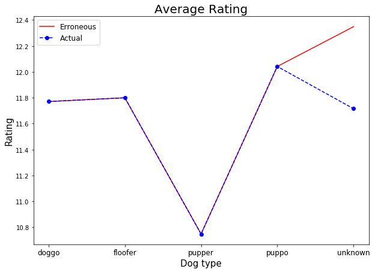

### Insight 2: Does the dog type influence the followers interactions (retweets and likes)

Simply computing the mean with `.mean()` works here!

The `puppo` dog type is found to have attracted the highest followers interaction on the WeRateDogs twitter page. On the other hand, `pupper` have the least average interaction.

#### Visualization

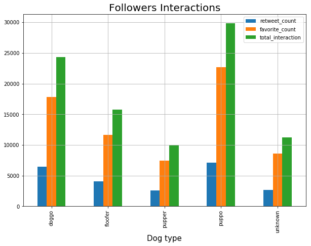

### Insight 3: What is the distribution of monthly activities (number of dog ratings done) of WeRateDogs?

We create the feature columns for year and month from the timestamp feature. Then count the activities (number of dog ratings done) by WeReateDogs.

We observe a decline in the monthly activities of WeRateDogs. The brand started out rating about 300 dogs in their first month, and have an average of around 50 dog ratings in the last few months.

#### Visualization

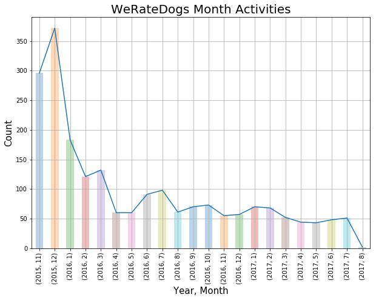